# ENEC 891 Fall 2019 Final

Grace Di Cecco

12/11/2019

## Introduction

Anthropogenic change is impacting ecological communities through a variety of mechanisms: two important drivers of change are land use and climate change. Species are impacted by changes in mean temperature and by both total habitat loss and habitat fragmentation (Haddad et al., 2015; Parmesan & Yohe, 2003). While studies have not found consistent local losses in biodiversity in many taxonomic groups, there has been evidence of turnover above levels predicted by null or neutral models (Dornelas et al., 2014; Vellend et al., 2017). As a result, there is a need for studies examining community compositional change and the importance of anthropogenic change drivers influencing that turnover.

Using long-term observational data sets of North American breeding bird communities, the Breeding Bird Survey, I will assess the relative contribution of climate change (measured as mean minimum and maximum temperature during the breeding season) and land use change (change in forest cover and change in forest edge density) in driving turnover in breeding bird communities at multiple scales. I predict that at smaller scales, land use change drivers will have stronger explanatory power in a model of species turnover, while at larger scales, climatic changes will be more important.

In order to assess the sensitivity of the ability of these models to detect change in bird species turnover, I conduct a power analysis to answer two questions: 1) what is the change in power of the model to detect effects of explanatory variables as BBS survey locations are aggregated to larger scales and 2) given that BBS routes are about half as dense in the western US as they are in the eastern US, how does this spatial bias impact the power of this analysis?

## Data cleaning

Here I assessed changes in breeding bird communities between 1990 and 2017 excluding nocturnal species, water birds, and birds of prey as these groups are not well sampled by the BBS point count methodology.

I determined land cover within a 5-km buffer at 30 by 30 meter resolution around each forested BBS survey route from the National Landcover Database (NLCD) for US routes and the Agriculture and Agri-food Canada Land Use dataset (AAFC) for Canadian routes (Agriculture and Agri-food Canada, 2015; Vogelmann et al., 2001; Yang et al., 2018). I simplified NLCD land cover to eight classes to enable comparison between the 1992 and 2016 datasets: mixed, deciduous, and coniferous forest were grouped into one forest class, and high, medium, and low-density urban were grouped into one class. I measured forest fragmentation at each BBS survey route in 1992 and 2016 for US routes and 1990 and 2010 for Canadian routes using edge density, which is equal to the sum of the perimeters of all forest patches in a landscape divided by landscape area (Vanderwal, Falconi, Januchowski, & Shoo, 2019). I calculated the change in forest edge density and the change in proportion forest cover between 1992 and 2016 for US routes from the NLCD, and change between 1990 and 2010 for Canadian routes from the AAFC, and divided values by the number of years of change the dataset represents (25 for NLCD, 21 for AAFC). Low values of forest edge density indicate mostly intact forests covering the landscape, while higher values indicate more fragmented forests. BBS routes with greater than 50% of the total change in edge density during the time period occurring between 2013 and 2016 were removed from the analysis, to ensure that bird communities had sufficient time to respond to changing conditions on the survey landscape.

I calculated average minimum and maximum temperature at a 5km buffer around each forested BBS survey route from monthly Daymet temperature data (Thornton et al., 2018) for the breeding season at 1-km2 resolution (May, June, July) and used simple linear regression to determine the trend in annual average breeding season minimum and maximum temperature from 1992 to 2016 on US routes and 1990 to 2010 on Canadian routes.

```r
### Read in data

## BBS

routes <- read.csv("/Volumes/hurlbertlab/Databases/BBS/2017/bbs_routes_20170712.csv")
weather <- read.csv("/Volumes/hurlbertlab/Databases/BBS/2017/bbs_weather_20170712.csv")
counts <- read.csv("/Volumes/hurlbertlab/Databases/BBS/2017/bbs_counts_20170712.csv")
species <- read.csv("/Volumes/hurlbertlab/Databases/BBS/2017/bbs_species_20170712.csv")

routes$stateroute <- routes$statenum*1000 + routes$route
weather$stateroute <-weather$statenum*1000 + weather$route
RT1 <- subset(weather, runtype == 1, select = c("stateroute", "year"))
RT1.routes <- merge(RT1, routes[ , c("countrynum", "statenum", "stateroute", "latitude", "longitude","bcr")], by = "stateroute", all.x = TRUE)
counts$stateroute <- counts$statenum*1000 + counts$route

# Diurnal land birds, no birds of prey
species_list <- species %>%
  filter(aou > 2880) %>%
  filter(aou < 3650 | aou > 3810) %>%
  filter(aou < 3900 | aou > 3910) %>%
  filter(aou < 4160 | aou > 4210) %>%
  filter(aou != 7010) %>%
  filter(sporder != "Accipitriformes",
         sporder != "Falconiformes",
         sporder != "Anseriformes",
         sporder != "Cathartiformes")

counts.subs <- counts %>%
  inner_join(RT1.routes, by = c("statenum", "stateroute", "year")) %>% # Remove RT = 0 route-years
  filter(aou %in% species_list$aou) %>% # Only diurnal land bird species, no birds of prey
  filter(rpid == 101) %>%
  filter(year >= 1990, year < 2017)

## BCRs

bcrs <- read_sf("/Volumes/hurlbertlab/DiCecco/bcr_terrestrial_shape/BCR_terrestrial_master.shp") %>%
  filter(COUNTRY == "USA" | COUNTRY == "CANADA") %>%
  st_crop(c(xmin = -178, ymin = 18.9, xmax = -53, ymax = 60)) %>%
  filter(PROVINCE_S != "ALASKA" & PROVINCE_S != "HAWAIIAN ISLANDS" & PROVINCE_S != "NUNAVUT" & PROVINCE_S != "NORTHWEST TERRITORIES" & PROVINCE_S != "YUKON") %>%
  filter(WATER == 3)

## ENV change at BBS routes

env_change <- read.csv("data/bbs_route_env_change.csv", stringsAsFactors = F) %>%
  rename(cover_change = "deltaProp",
         edge_change = "deltaED")

## ENV change at BCRs

bcr_change <- env_change %>%
  left_join(dplyr::select(routes, stateroute, longitude, latitude)) %>%
  st_as_sf(coords = c("longitude", "latitude")) %>%
  st_set_crs(st_crs(bcrs)) %>%
  st_intersection(bcrs) %>%
  group_by(BCR) %>%
  summarize(mean_tmax = mean(tmax, na.rm = T),
            mean_tmin = mean(tmin, na.rm = T),
            mean_cover = mean(cover_change, na.rm = T),
            mean_edge = mean(edge_change, na.rm = T)) %>%
  st_set_geometry(NULL)
```

## Power analysis

Species turnover for each BBS community was calculated using the Jaccard dissimilarity index (Jaccard, 1912). I calculated Jaccard dissimilarity between species observed from 1990-1994 and 2013-2017. Species occurring at least two out of five years were included. Jaccard dissimilarity (with a logit transformation) was used as the response variable in a linear model with four predictor variables: trend in minimum temperature during the breeding season, trend in maximum temperature during the breeding season, change in proportion forest cover per year, and change in forest edge density per year.

For the scale analysis, I fit this model at two scales: each BBS route as a data point and aggregating BBS routes to the ecoregion level, using Bird Conservation Regions from the North American Bird Conservation Initiative (http://nabci-us.org/resources/bird-conservation-regions-map/). I averaged environmental change across routes in an ecoregion, and used the pool of species observed in the two time windows in the whole ecoregion to calculate Jaccard dissimilarity at the coarser spatial scale.

To examine the effect of spatial bias in BBS routes, I compared the route-level model to a model in which I randomly subsampled BBS routes east of -100 degrees West to have the same sampling density as routes west of -100 degrees West, which resulted in a decrease in sample size of about 50% for the eastern US.

I used an analytic soution to calculate power for each linear model using R packge “pwr” (Champely et al., 2018). For the observed model R<sup>2</sup> and degrees of freedom, I calculated power for p-values from 0.0001 to 0.2.

```r
### Format data - species turnover at 2 scales - route, BCR

temporal_turnover <- function(specieslist1, specieslist2) {
  gamma <- length(unique(c(specieslist1, specieslist2)))
  intersec <- length(specieslist1[specieslist1 %in% specieslist2])
  jaccard <- (gamma - intersec)/gamma
  success <- gamma - intersec
  fail <- intersec
  res <- data.frame(jaccard = jaccard, success = success, fail = fail)
  return(res)
}

route_turnover <- counts.subs %>%
    filter(stateroute %in% env_change$stateroute) %>%
    group_by(stateroute) %>%
    nest() %>%
    mutate(jaccard = purrr::map(data, ~{
      df <- .

      df_early <- df %>%
        filter(year <= 1994) %>%
        group_by(aou) %>%
        filter(n_distinct(year) > 1) %>%
        ungroup()
      sp_early <- unique(df_early$aou)

      df_late <- df %>%
        filter(year >= 2013) %>%
        filter(n_distinct(year) > 1) %>%
        ungroup()
      sp_late <- unique(df_late$aou)

      temporal_turnover(sp_early, sp_late)
    })) %>%
    dplyr::select(-data) %>%
  unnest(cols = c(jaccard)) %>%
  left_join(env_change)

bcr_turnover <- counts.subs %>%
  filter(stateroute %in% env_change$stateroute) %>%
  group_by(bcr) %>%
  nest() %>%
  mutate(jaccard = purrr::map(data, ~{
    df <- .

    df_early <- df %>%
      filter(year <= 1994) %>%
      group_by(aou) %>%
      filter(n_distinct(year) > 1) %>%
      ungroup()
    sp_early <- unique(df_early$aou)

    df_late <- df %>%
      filter(year >= 2013) %>%
      filter(n_distinct(year) > 1) %>%
      ungroup()
    sp_late <- unique(df_late$aou)

    temporal_turnover(sp_early, sp_late)
  })) %>%
  dplyr::select(-data) %>%
  unnest(cols = c(jaccard)) %>%
  left_join(bcr_change, by = c("bcr" = "BCR"))

### Build model for power analysis: species turnover at a route over time ~ env change at 3 scales

e <- min(route_turnover$jaccard, na.rm = T)/2

logit <- function(x) {
  logit <- log(x/(1 - x))
  return(logit)
}

logit_e <- function(x) {
  logit <- log((x- e)/(1 - (x - e)))
  return(logit)
}

route_turnover_model <- route_turnover %>%
  filter(!is.na(jaccard)) %>%
  mutate(logit_jac = case_when(
                               jaccard == 1 ~ logit_e(jaccard),
                               jaccard < 1 ~ logit(jaccard)))

e <- min(bcr_turnover$jaccard, na.rm = T)/2

bcr_turnover_model <- bcr_turnover %>%
  filter(!is.na(jaccard)) %>%
  mutate(logit_jac = case_when(
    jaccard == 1 ~ logit_e(jaccard),
    jaccard < 1 ~ logit(jaccard)))

route_turnover_mod <- lm(logit_jac ~ tmax + tmin + cover_change + edge_change, data = route_turnover_model)

bcr_turnover_mod <- lm(logit_jac ~ mean_tmax + mean_tmin + mean_cover + mean_edge, data = bcr_turnover_model)

### Power analysis of current model: scale of analysis

power_analysis <- function(model, alpha) {
  sum <- summary(model)
  rsq <- sum$r.squared
  f2 <- rsq/(1 - rsq)
  numdf <- sum$fstatistic[[2]]
  dendf <- sum$fstatistic[[3]]

  pwr.f2.test(numdf, dendf, f2, alpha)
}

power_analysis_output <- function(model, pvals) {
  map_df(pvals, ~{
    p <- .
    pwr <- power_analysis(model, p)
    flatten_dfc(pwr)
  })
}

pvals <- seq(0.0001, 0.2, by = 0.005)

route_power <- power_analysis_output(route_turnover_mod, pvals) %>%
  mutate(mod = "Stateroute")
bcr_power <- power_analysis_output(bcr_turnover_mod, pvals) %>%
  mutate(mod = "BCR")

power_results <- bind_rows(route_power, bcr_power)

### Power analysis: artificially decrease number of routes, how does power change

# What would power be for whole US model if I resample from routes to give same density in east as western

na_area_west <- bcrs %>%
  st_crop(c(xmin = -178, ymin = 18.9, xmax = -100, ymax = 60)) %>%
  st_union() %>%
  st_area()

na_area_east <- bcrs %>%
  st_crop(c(xmin = -100, ymin = 18.9, xmax = -50, ymax = 60)) %>%
  st_union() %>%
  st_area()

regional_power <- route_turnover_model %>%
  left_join(dplyr::select(routes, stateroute, latitude, longitude)) %>%
  mutate(region = case_when(longitude < -100 ~ "West",
                            longitude > -100 ~ "East")) %>%
  group_by(region) %>%
  summarize(nRoutes = n_distinct(stateroute))

west_density <- regional_power$nRoutes[[2]]/na_area_west
east_new_nRoutes <- as.numeric(round(west_density*na_area_east))

eastern_routes <- route_turnover_model %>%
  left_join(dplyr::select(routes, stateroute, latitude, longitude)) %>%
  mutate(region = case_when(longitude < -100 ~ "West",
                            longitude > -100 ~ "East")) %>%
  filter(region == "East")

new_eastern_routes <- eastern_routes[sample(nrow(eastern_routes), east_new_nRoutes), ]

subsampled_bbs <- route_turnover_model %>%
  left_join(dplyr::select(routes, stateroute, latitude, longitude)) %>%
  mutate(region = case_when(longitude < -100 ~ "West",
                            longitude > -100 ~ "East")) %>%
  filter(region == "West") %>%
  bind_rows(new_eastern_routes)

subsampled_mod <- lm(logit_jac ~ tmax + tmin + cover_change + edge_change, data = subsampled_bbs)

subsampled_power <- power_analysis_output(subsampled_mod, pvals) %>%
  mutate(mod = "Western US density") %>%
  bind_rows(filter(route_power, mod == "Stateroute"))
```

## Results

#### Scale analysis

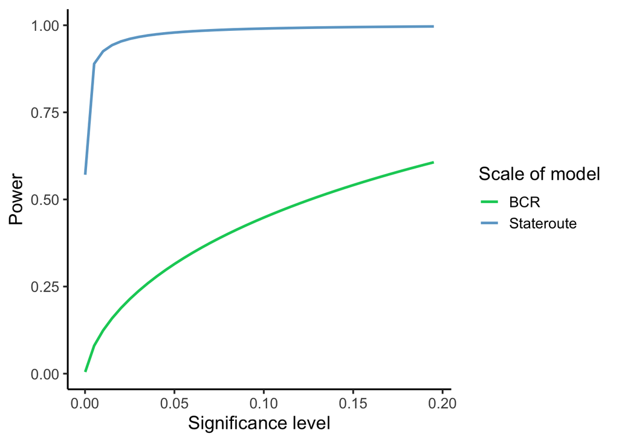

#### Spatial bias analysis

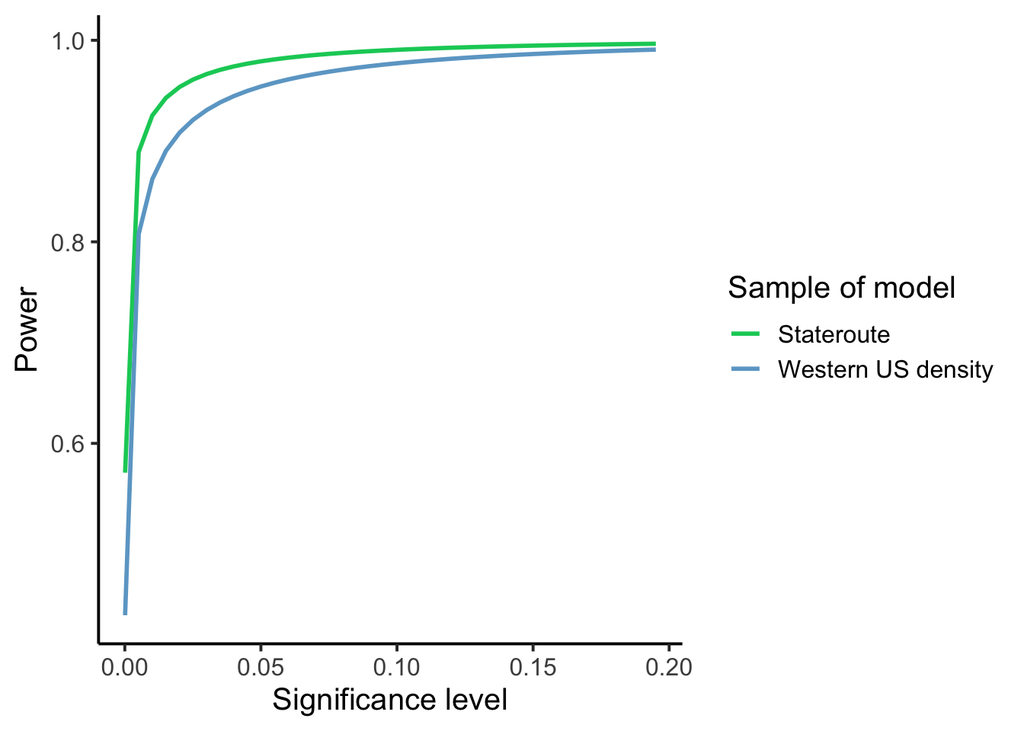

## Conclusions

### Works Cited

Agriculture and Agri-Food Canada. (2015). Land Use 1990, 2000 & 2010. Retrieved from https://open.canada.ca/data/en/dataset/18e3ef1a-497c-40c6-8326-aac1a34a0dec

Champely, S., Ekstrom, C., Dalgaard, P., Gill, J., Weibelzahl, S., Anandkumar, A., Ford, C., Volcic, R., & De Rosario, H. (2018). Package ‘pwr.’ https://CRAN.R-project.org/package=pwr

Dornelas, M., Gotelli, N. J., McGill, B., Shimadzu, H., Moyes, F., Sievers, C., & Magurran, A. E. (2014). Assemblage time series reveal biodiversity change but not systematic loss. Science, 344, 296–299.

Haddad, N. M., Brudvig, L. A., Clobert, J., Davies, K. F., Gonzalez, A., Holt, R. D., … Townshend, J. R. (2015). Habitat fragmentation and its lasting impact on Earth’s ecosystems. Science Advances. https://doi.org/10.1126/sciadv.1500052

Jaccard, P. (1912) The distribution of the flora in the alpine zone. New Phytologist, 11, 37–50.

Parmesan, C., & Yohe, G. (2003). A globally coherent fingerprint of climate change impacts across natural systems. Nature. https://doi.org/10.1038/nature01286

Thornton, P. E., Thornton, M. M., Mayer, B. W., Wei, Y., Devarakonda, R., Vose, R. S., & Cook, R. B. (2018). Daymet: Daily Surface Weather Data on a 1-km Grid for Northa America, Version 3. https://doi.org/https://doi.org/10.3334/ORNLDAAC/1328

Vanderwal, A. J., Falconi, L., Januchowski, S., & Shoo, L. (2019). Package ‘SDMTools .’ https://CRAN.R-project.org/package=SDMTools

Vellend, M., Dornelas, M., Baeten, L., Beauséjour, R., Brown, C. D., De Frenne, P., … Sievers, C. (2017). Estimates of local biodiversity change over time stand up to scrutiny. Ecology. https://doi.org/10.1002/ecy.1660

Vogelmann, J. E., Van Driel, N., Howard, S. M., Yang, L., Larson, C. R., & Wylie, B. K. (2001). Completion of the 1990s National Land Cover Data Set for the Conterminous United States From LandSat Thematic Mapper Data and Ancillary Data Sources. Photogrammetric Engineering & Remote Sensing2, 67(6), 650–662.

Yang, L., Jin, S., Danielson, P., Homer, C., Gass, L., Bender, S. M., … Xian, G. (2018). A new generation of the United States National Land Cover Database: Requirements, research priorities, design, and implementation strategies. ISPRS Journal of Photogrammetry and Remote Sensing, 146(August), 108–123. https://doi.org/10.1016/j.isprsjprs.2018.09.006